# Model Selection

Linear Models

Jim Peterson, Oregon State University https://sites.google.com/site/rforfishandwildlifegrads/home/mumin_usage_examples

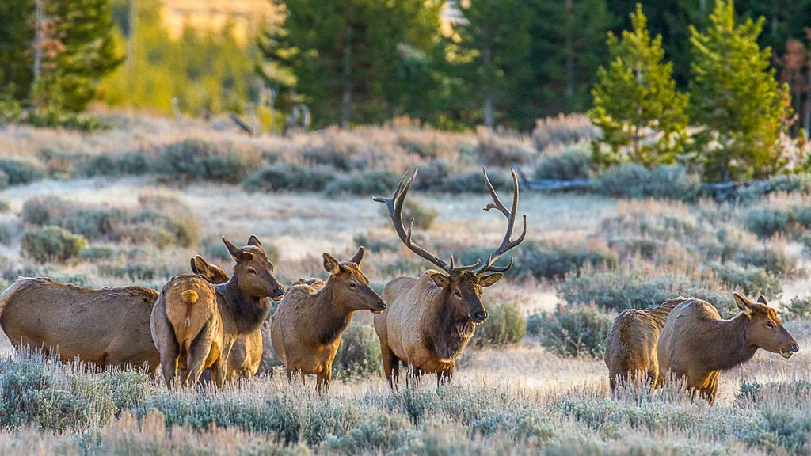

Habitat Selection by Elk

```r
#many of our tables output in the console are really wide; expand limits [width] to fit them all in,
#otherwise they wrap awkwardly
options(width = 90)
#https://bookdown.org/yihui/rmarkdown-cookbook/text-width.html

#matrix(runif(100), ncol = 20) #test code to display adjusted width
```

```r
data_elk<-read.csv("../data/elk_example.csv")
```

The data includes three response variables; count, density, and presence.

The data includes five predictor variables: elev (elevation), slope (gradient), area, distance (to nearest population), and pct.cover (% cover). Let’s see what they look like.

```r
print(dfSummary(data_elk,
                varnumbers   = FALSE,
                valid.col    = FALSE,
                graph.magnif = 0.75),
      max.tbl.height = 400, # if this is turned off, entire table displays
      method = "render")
```

Data Frame Summary

data_elk

**Dimensions**: 255 x 8  
**Duplicates**: 0

| **Variable** | **Stats / Values** | **Freqs (% of Valid)** | **Graph** | **Missing** |
| --- | --- | --- | --- | --- |
| count [integer] | Mean (sd) : 11.4 (14.3) min ≤ med ≤ max: 0 ≤ 5 ≤ 77 IQR (CV) : 18 (1.3) | 46 distinct values |  | 0 (0.0%) |
| density [numeric] | Mean (sd) : 0 (0) min ≤ med ≤ max: 0 ≤ 0 ≤ 0.1 IQR (CV) : 0 (1.2) | 119 distinct values |  | 0 (0.0%) |
| presence [integer] | Min : 0 Mean : 0.6 Max : 1 | 0 : 96 ( 37.6% ) 1 : 159 ( 62.4% ) |  | 0 (0.0%) |
| elev [integer] | Mean (sd) : 322.5 (145) min ≤ med ≤ max: 49 ≤ 288 ≤ 936 IQR (CV) : 170.5 (0.4) | 191 distinct values |  | 0 (0.0%) |
| slope [numeric] | Mean (sd) : 0.1 (0) min ≤ med ≤ max: 0 ≤ 0.1 ≤ 0.1 IQR (CV) : 0 (0.4) | 15 distinct values |  | 0 (0.0%) |
| area [integer] | Mean (sd) : 1042.8 (381.6) min ≤ med ≤ max: 110 ≤ 1042 ≤ 2078 IQR (CV) : 542.5 (0.4) | 237 distinct values |  | 0 (0.0%) |
| distance [numeric] | Mean (sd) : 305.8 (100) min ≤ med ≤ max: 36.1 ≤ 306.9 ≤ 688.6 IQR (CV) : 140 (0.3) | 246 distinct values |  | 0 (0.0%) |
| pct.cover [integer] | Mean (sd) : 52.9 (22.6) min ≤ med ≤ max: 13 ≤ 55 ≤ 91 IQR (CV) : 38 (0.4) | 75 distinct values |  | 0 (0.0%) |

Generated by summarytools 1.1.4 ([R](https://www.r-project.org/) version 4.4.2)  
2025-10-08

Lets look at the relationships among the predictor variables to see if there is potential redundancy (colinearity); response variable not included.

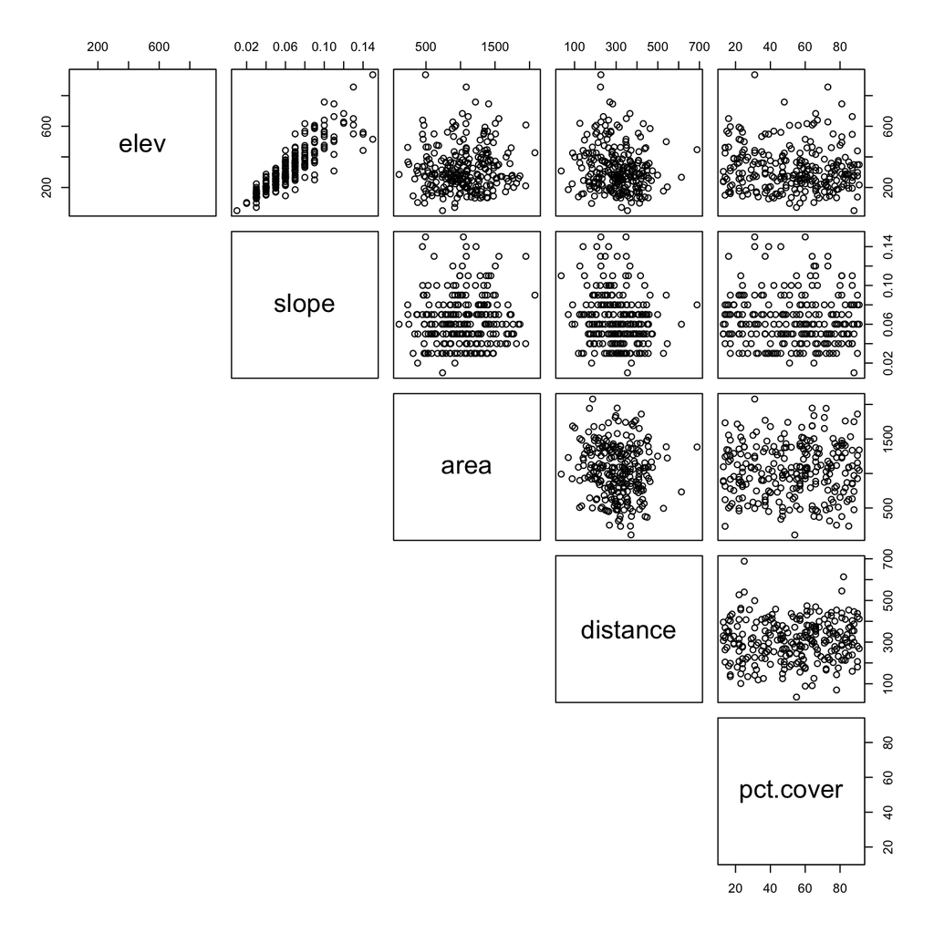

```r
#check for co-linearity among the five predictor variables (response variable should NOT be included)
pairs(data_elk[,4:8], lower.panel = NULL) #use all rows of columns 4 through 8
```

Elevation and Slope look closely related, which means they are very likely redundant information representing the same phenomenon, but we will ignore for now.

One very important thing you should do next is change the global options for how R functions handle missing data. By making this change, a function will not work if data are missing. This is required if you use the `dredge` function for exploratory data analysis.

```r
# change na. action
options(na.action = "na.fail")
```

Ok we’re ready to go. Let’s fit four candidate models that explain variation in animal density. Ideally, these models would represent biological hypotheses. Given the nature of the response, we’ll use ordinary linear regression with the `lm` function.

```r
#First, fit 4 candidate linear models to explain variation in density
mod1 <- lm(density ~ distance + elev, data = data_elk)
mod2 <- lm(density ~ slope + pct.cover, data = data_elk)
mod3 <- lm(density ~ slope + distance, data = data_elk)
mod4 <- lm(density ~ slope + distance + elev, data = data_elk)
```

We can now use the `model.sel` function to conduct model selection. The default model selection criteria is Akaike’s information criteria (AIC) with small sample bias adjustment, AIC<sub>c</sub>. Here we’ll create an object `out.put` that contains all of the model selection information.

```r
# use the model.sel function to conduct model selection
# and put output into object out.put
out.put <- model.sel(mod1, mod2, mod3, mod4)
out.put
```

```
## Model selection table
##          (Int)       dst       elv   pct.cvr      slp df  logLik    AICc delta weight
## mod1 -0.013280 5.195e-05 1.832e-05                     4 863.907 -1719.7  0.00  0.720
## mod4 -0.013080 5.181e-05 2.002e-05           -0.01096  5 863.944 -1717.6  2.01  0.264
## mod3 -0.012920 5.207e-05                      0.08634  4 860.130 -1712.1  7.55  0.016
## mod2  0.003614                     2.777e-05  0.05374  4 819.492 -1630.8 88.83  0.000
## Models ranked by AICc(x)
```

The models are sorted from best (top) to worst (bottom). Note that the function does not use the whole name for model parameters, but creates abbreviations. Looks like `mod1`, containing an intercept (Int), distance (dst), and elevation(elev) is best with a weight of 0.72. It is 0.72/0.264 = 2.72 times more likely to be the best explanation (hypothesis) for variation in density.

Quite often we need to express model selection uncertainty by specifying a confidence set of models using some rule. Here we can use the `subset` function to select the models that meet the criteria. Note that the weights are re-normalized for the models selected. That is, they are adjusted so that they add to one. I hate this feature–not very helpful.

```r
# create a confidence set of models using the subset function
# select models with delta AICc less than 5
# IMPORTANT: Weights have been renormalized!!
subset(out.put, delta <5)
```

```
## Model selection table
##         (Int)       dst       elv      slp df  logLik    AICc delta weight
## mod1 -0.01328 5.195e-05 1.832e-05           4 863.907 -1719.7  0.00  0.732
## mod4 -0.01308 5.181e-05 2.002e-05 -0.01096  5 863.944 -1717.6  2.01  0.268
## Models ranked by AICc(x)
```

```r
# select models using Royall's 1/8 rule for strength of evidence
#https://www.stat.fi/isi99/proceedings/arkisto/varasto/roya0578.pdf
# IMPORTANT: Weights have been renormalized!!
subset(out.put, 1/8 < weight/max(out.put$weight))
```

```
## Model selection table
##         (Int)       dst       elv      slp df  logLik    AICc delta weight
## mod1 -0.01328 5.195e-05 1.832e-05           4 863.907 -1719.7  0.00  0.732
## mod4 -0.01308 5.181e-05 2.002e-05 -0.01096  5 863.944 -1717.6  2.01  0.268
## Models ranked by AICc(x)
```

Not much different than delta < 5 above. Let’s try another criteria based on the cumulative sum of the model weights.

```r
# select models 95% cumulative weight criteria
# IMPORTANT: Weights have been renormalized!!
subset(out.put, cumsum(out.put$weight) <= .95)
```

```
## Model selection table
##         (Int)       dst       elv df  logLik    AICc delta weight
## mod1 -0.01328 5.195e-05 1.832e-05  4 863.907 -1719.7     0      1
## Models ranked by AICc(x)
```

In most circumstances, you would like to include model selection results in a table in a report, publication, or thesis. Here, we need to coerce the output from the `model.sel` function into a dataframe. Columns 6-10 of that data frame contain what we want. How do I know that? I first created the dataframe and used the `str` function to see what elements were in the dataframe.

```r
# coerce the object out.put into a data frame
# elements 6-10 in out.put have what we want
sel.table <- as.data.frame(out.put)[6:10]
sel.table
```

```
##      df   logLik      AICc     delta       weight
## mod1  4 863.9067 -1719.653  0.000000 7.196856e-01
## mod4  5 863.9437 -1717.646  2.006937 2.638408e-01
## mod3  4 860.1296 -1712.099  7.554120 1.647353e-02
## mod2  4 819.4916 -1630.823 88.830152 3.697604e-20
```

This is a bit messy and not ready for any report. Let’s clean this up a bit and export as a gt table and .csv file.

```r
# Round selected numeric columns to 2 decimals
sel.table$logLik <- round(sel.table$logLik, 2)
sel.table$AICc   <- round(sel.table$AICc, 2)
sel.table$delta  <- round(sel.table$delta, 2)
sel.table$weight <- round(sel.table$weight, 2)

# Assume you have models already built: mod1, mod2, mod3, mod4
mods <- list(mod1, mod4, mod3, mod2) #note the order is from best to worst model

# Extract formulas (single line per model)
labs <- vapply(mods, function(m) {
  paste(deparse(formula(m), width.cutoff = 500), collapse = "")
}, character(1))

# Add model formulas as a new column
out.df <- cbind(Model = labs, as.data.frame(sel.table))
rownames(out.df) <- NULL   # cleaner row labels

# Make a gt table
gt_tbl <- gt::gt(out.df) |>
  tab_header(
    title = "Model Selection Results for Elk Habitat Selection",
    subtitle = "Formulas shown for each candidate model"
  ) |>
  fmt_number(
    columns = c(logLik, AICc, delta, weight),
    decimals = 2
  ) |>
  cols_label(
    Model = "Formula",
    df = "K", #by convention we use K for AIC comparison
    logLik = "LogLik",
    AICc = "AICc",
    delta = "ΔAICc",
    weight = "Weight"
  ) |>
  tab_options(
    table.font.size = px(14),
    heading.align = "center"
  )

gt_tbl
```

Model Selection Results for Elk Habitat Selection

Formulas shown for each candidate model

| Formula | K | LogLik | AICc | ΔAICc | Weight |
| --- | --- | --- | --- | --- | --- |
| density ~ distance + elev | 4 | 863.91 | −1,719.65 | 0.00 | 0.72 |
| density ~ slope + distance + elev | 5 | 863.94 | −1,717.65 | 2.01 | 0.26 |
| density ~ slope + distance | 4 | 860.13 | −1,712.10 | 7.55 | 0.02 |
| density ~ slope + pct.cover | 4 | 819.49 | −1,630.82 | 88.83 | 0.00 |

```r
# Save as PNG into "../tables/"
gtsave(gt_tbl, filename = "../tables/My model selection gt.png")
```

Now that’s more like it. Models are from best to worst fitting. You can usually drop AIC<sub>c</sub> if the Log Likelihood (logLik) is in the table, but we’ll leave it here. This is about ready for a report, so let’s write it to a comma separated file.

```r
# write to a file, here a comma separated values format
write.csv(out.df,"../tables/My model selection table.csv", row.names = F)
```

```r
# model selection table; sorted by BIC
model.sel(mod1, mod2, mod3, mod4, rank = BIC)
```

```
## Model selection table
##          (Int)       dst       elv   pct.cvr      slp df  logLik     BIC delta weight
## mod1 -0.013280 5.195e-05 1.832e-05                     4 863.907 -1705.6  0.00  0.919
## mod4 -0.013080 5.181e-05 2.002e-05           -0.01096  5 863.944 -1700.2  5.47  0.060
## mod3 -0.012920 5.207e-05                      0.08634  4 860.130 -1698.1  7.55  0.021
## mod2  0.003614                     2.777e-05  0.05374  4 819.492 -1616.8 88.83  0.000
## Models ranked by BIC(x)
```

```r
#consistent AIC with Fishers information matrix
model.sel(mod1, mod2, mod3, mod4, rank = CAICF)
```

```
## Model selection table
##          (Int)       dst       elv   pct.cvr      slp df  logLik   CAICF delta weight
## mod3 -0.012920 5.207e-05                      0.08634  4 860.130 -1642.9  0.00  0.993
## mod1 -0.013280 5.195e-05 1.832e-05                     4 863.907 -1633.1  9.80  0.007
## mod4 -0.013080 5.181e-05 2.002e-05           -0.01096  5 863.944 -1619.2 23.66  0.000
## mod2  0.003614                     2.777e-05  0.05374  4 819.492 -1565.5 77.37  0.000
## Models ranked by CAICF(x)
```

There also are `MuMin` functions for calculating model selection criteria, such as AIC, AIC<sub>c</sub>, BIC and Mallows Cp, an ad hoc model selection criterion, not recommended. Here lets only compare two models using AIC.

```r
#AIC
AIC(mod1, mod2)
```

```
##      df       AIC
## mod1  4 -1719.813
## mod2  4 -1630.983
```

Note that above, the df is actually the number of model parameters, usually defined as K.

The **relative importance of individual parameters** can also be examined using the model weights. Here, the **Akaike weights** for each model that contains the parameter of interest are summed. These have been defined as importance weights and you can obtain them from a `model.sel` object using the “importance” function.

They can be interpreted as the probability that a variable is part of the best model, given the data and the candidate set. High values (close to 1) indicate strong support for including the variable, while low values (close to 0) suggest little support.

**Caveats**

- Relative, not absolute: These are not effect sizes. A variable with sw = 0.9 is not “twice as important” as one with sw = 0.45. It just has more consistent support across the candidate models.
- Model set–dependent: Importance weights depend on the models you included. If the candidate set is poorly specified, the weights can be misleading.
- Collinearity issues: Correlated predictors may “share” importance, making their weights look lower than expected.

```r
# Importance weights for individual predictor variables
# calculated using the `sw` function

sw(out.put) #Per-variable sum of model weights
```

```
##                      distance elev  slope pct.cover
## Sum of weights:          1     0.98  0.28 <0.01
## N containing models:     3        2     3     1
```

Looking at the output above, there is plenty of evidence for *distance* and *elev* (weights close to one), but much less for *pct.cover*. The number of candidate models in which a parameter occurs can have a big effect of the importance weight. For example, the intercept is included in all models, so the importance weight is 1 (hence it is never shown). In the above output, *pct.cover* is in only one model so it is weighted with caution.

**Model averaging is a way to incorporate model selection uncertainty.** Here, the parameter estimates for each candidate model are weighted using their corresponding model weights and summed. There are two methods for model-averaging defined by Burnham and Anderson; where parameter estimates are averaged over all models in which predictor *Xi* occurs and where parameter estimates are averaged over all models, not just those in which predictor *Xi* occurs.

`MuMIn` function `model.avg` conducts both types of model averaging and reports the first type of model averaging as “subset” and the second type as “full”.

```r
# Model average using all candidate models, always use revised.var = TRUE
MA.ests <- model.avg(out.put, revised.var = TRUE)
MA.ests
```

```
##
## Call:
## model.avg(object = out.put, revised.var = TRUE)
##
## Component models:
## '12'  '124' '14'  '34'
##
## Coefficients:
##        (Intercept)     distance         elev        slope    pct.cover
## full   -0.01322053 5.191484e-05 1.846475e-05 -0.001469396 1.026921e-24
## subset -0.01322053 5.191484e-05 1.877402e-05 -0.005241959 2.777260e-05
```

Another useful `MuMIn` function is `dredge`. However, you should only use is for exploratory purposes. Data dredging is strongly discouraged and can result in spurious (and irrelevant or worse, wrong) results and inference. So read the message below and users beware.

```r
## FOR EXPLORATORY PURPOSES ONLY!!! NEVER EVER DO THIS FOR A REAL
## STUDY
# fit model with all parameters
all.parms <- lm(density ~ slope + distance + elev + pct.cover, data = data_elk)

summary(all.parms)
```

```
##
## Call:
## lm(formula = density ~ slope + distance + elev + pct.cover, data = data_elk)
##
## Residuals:
##        Min         1Q     Median         3Q        Max
## -0.0166379 -0.0069336 -0.0001803  0.0059001  0.0256340
##
## Coefficients:
##               Estimate Std. Error t value Pr(>|t|)
## (Intercept) -1.436e-02  2.592e-03  -5.540 7.67e-08 ***
## slope       -1.187e-02  4.060e-02  -0.292  0.77029
## distance     5.162e-05  5.248e-06   9.837  < 2e-16 ***
## elev         2.044e-05  7.261e-06   2.815  0.00527 **
## pct.cover    2.377e-05  2.291e-05   1.037  0.30061
## ---
## Signif. codes:  0 '***' 0.001 '**' 0.01 '*' 0.05 '.' 0.1 ' ' 1
##
## Residual standard error: 0.008236 on 250 degrees of freedom
## Multiple R-squared:  0.3136, Adjusted R-squared:  0.3026
## F-statistic: 28.55 on 4 and 250 DF,  p-value: < 2.2e-16
```

```r
# the dredge function fits all combinations
# of the variables in the all.parms model fit above
results <- dredge(all.parms)
```

```
## Fixed term is "(Intercept)"
```

```r
results
```

```
## Global model call: lm(formula = density ~ slope + distance + elev + pct.cover, data = data_elk)
## ---
## Model selection table
##        (Int)       dst       elv   pct.cvr      slp df  logLik    AICc delta weight
## 4  -0.013280 5.195e-05 1.832e-05                     4 863.907 -1719.7  0.00  0.448
## 8  -0.014560 5.177e-05 1.860e-05 2.362e-05           5 864.448 -1718.7  1.00  0.272
## 12 -0.013080 5.181e-05 2.002e-05           -0.01096  5 863.944 -1717.6  2.01  0.164
## 16 -0.014360 5.162e-05 2.044e-05 2.377e-05 -0.01187  6 864.491 -1716.6  3.01  0.100
## 10 -0.012920 5.207e-05                      0.08634  4 860.130 -1712.1  7.55  0.010
## 14 -0.014000 5.191e-05           2.015e-05  0.08731  5 860.512 -1710.8  8.87  0.005
## 2  -0.006235 4.824e-05                               3 851.388 -1696.7 22.97  0.000
## 6  -0.006971 4.809e-05           1.474e-05           4 851.579 -1695.0 24.65  0.000
## 3   0.004224           1.331e-05                     3 821.497 -1636.9 82.76  0.000
## 7   0.002455           1.370e-05 3.106e-05           4 822.168 -1636.2 83.48  0.000
## 11  0.004913           2.128e-05           -0.05103  4 822.079 -1636.0 83.66  0.000
## 15  0.003126           2.184e-05 3.159e-05 -0.05204  5 822.777 -1635.3 84.34  0.000
## 9   0.005179                                0.05226  3 818.964 -1631.8 87.82  0.000
## 13  0.003614                     2.777e-05  0.05374  4 819.492 -1630.8 88.83  0.000
## 1   0.008517                                         2 816.516 -1629.0 90.67  0.000
## 5   0.007247                     2.399e-05           3 816.903 -1627.7 91.94  0.000
## Models ranked by AICc(x)
```

```r
# grab best supported models
subset(results, delta <5)
```

```
## Global model call: lm(formula = density ~ slope + distance + elev + pct.cover, data = data_elk)
## ---
## Model selection table
##       (Int)       dst       elv   pct.cvr      slp df  logLik    AICc delta weight
## 4  -0.01328 5.195e-05 1.832e-05                     4 863.907 -1719.7  0.00  0.455
## 8  -0.01456 5.177e-05 1.860e-05 2.362e-05           5 864.448 -1718.7  1.00  0.276
## 12 -0.01308 5.181e-05 2.002e-05           -0.01096  5 863.944 -1717.6  2.01  0.167
## 16 -0.01436 5.162e-05 2.044e-05 2.377e-05 -0.01187  6 864.491 -1716.6  3.01  0.101
## Models ranked by AICc(x)
```

```r
#grab best model
subset(results, delta == 0)
```

```
## Global model call: lm(formula = density ~ slope + distance + elev + pct.cover, data = data_elk)
## ---
## Model selection table
##      (Int)       dst       elv df  logLik    AICc delta weight
## 4 -0.01328 5.195e-05 1.832e-05  4 863.907 -1719.7     0      1
## Models ranked by AICc(x)
```

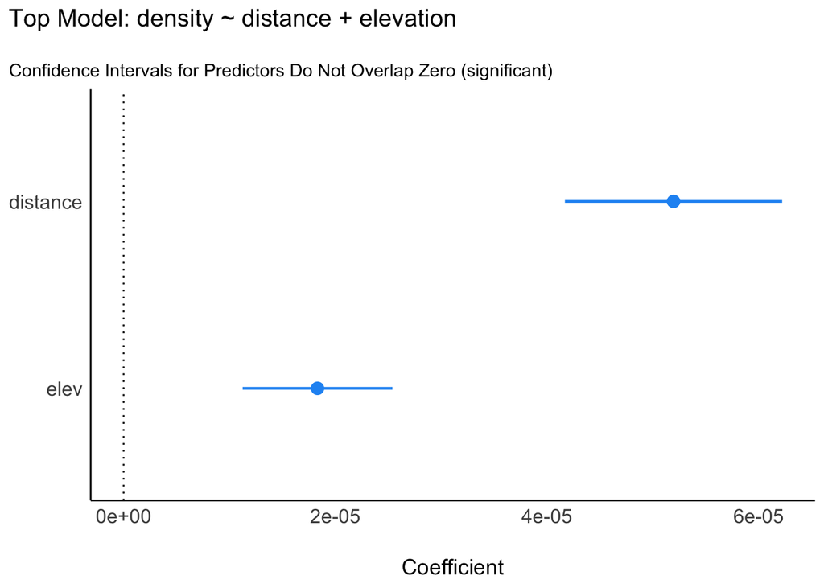

```r
top_model <- lm(formula = density ~ distance + elev, data = data_elk)

plot(parameters(top_model)) +
  ggplot2::labs(title = "Top Model: density ~ distance + elevation",
                subtitle = "Confidence Intervals for Predictors Do Not Overlap Zero (significant)")
```

```r
# but we likely don't care much about statistical significance; model likely would not have made it to the top if it didn't have a lot of predictive power.
```

```r
# calculate variable importance weights
sw(results)
```

```
##                      distance elev pct.cover slope
## Sum of weights:      1.00     0.98 0.38      0.28
## N containing models:    8        8    8         8
```

Notice above that every parameter is in the same number of models.

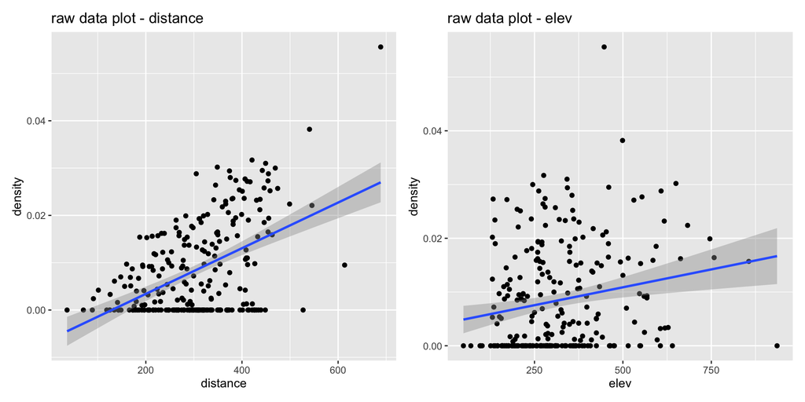

```r
p1 <- ggplot(data_elk, aes(distance, density)) +
  ggtitle("raw data plot - distance") +
  geom_point() +
  geom_smooth(method = "lm") +
  scale_x_continuous(limits = c(0, 700) +
  scale_y_continuous(limits = c(0, 0.06)))

p2 <- ggplot(data_elk, aes(elev, density)) +
  ggtitle("raw data plot - elev") +
  geom_point() +
  geom_smooth(method = "lm") +
  scale_x_continuous(limits = c(0, 1000) +
  scale_y_continuous(limits = c(0, 0.06)))

p1 + p2
```

- Note that this example probably needs a different error structure because prediction line drops to negative for distance values below 125. Lots of zeros suggests a poisson or zero-inflated poisson model might be a better fit. We will ignore this for now.

**Create partial regression plots (effect of each predictor adjusting for others)**

You can do this by plotting predicted values from the model across a grid of each predictor **while holding the others constant at their mean**. These are different than the raw data plots above.

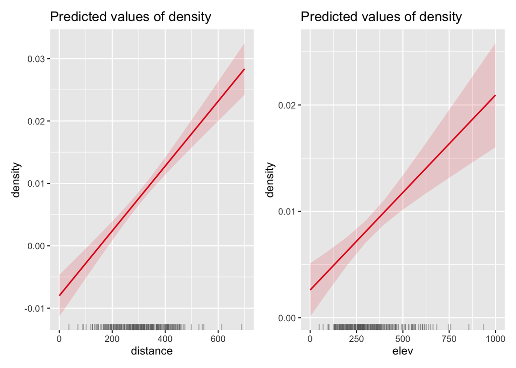

```r
#sjPlot might be easier

p3 <-
  sjPlot::plot_model(top_model, type = "pred", terms = "distance") +
  geom_rug(
    data = data_elk,
    aes(x = distance),
    inherit.aes = FALSE,
    sides = "b",
    alpha = 0.4,
    length = unit(0.02, "npc"),
    color = "gray40")

p4 <-
  sjPlot::plot_model(top_model, type = "pred", terms = "elev") +
  geom_rug(
    data = data_elk,
    aes(x = elev),
    inherit.aes = FALSE,
    sides = "b",
    alpha = 0.4,
    length = unit(0.02, "npc"),
    color = "gray40")

p3 + p4
```

Each of these `sjPlot` plots shows:

- The fitted regression line (partial effect of the predictor, after controlling for other variables [holding the others constant at their mean])
- A 95% confidence band around the prediction
- ‘rug plot’ tick marks along bottom indication location of data points on the x-axis
- Because its compatible with `ggplot2`, you could also put raw data points on with `geom_point`.

Wow, these predicted plots look similar to the raw data plots. Let’s put them next to each other for comparison.

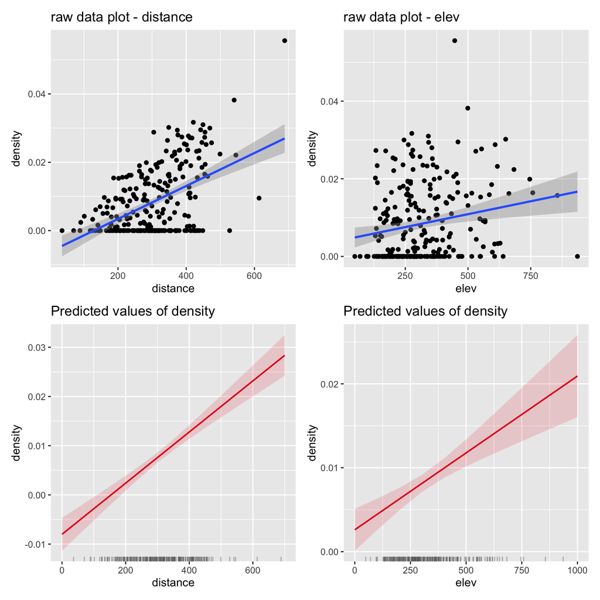

```r
(p1 + p2) / (p3 + p4)
```

Examples of how this is used (Peterson) to study habitat selection by fishes:

Reiman, B.E., J.T. Peterson, and D.L. Myers. 2006. Have Brook Trout Displaced Bull Trout in Streams of Central Idaho?: An Empirical Analysis of Distributions Along Elevation and Thermal Gradients Canadian Journal of Fisheries and Aquatic Sciences 63:63-78.

McCargo, J.W. and J.T. Peterson. 2010. An evaluation of the influence of seasonal base flow and geomorphic stream characteristics on Coastal Plain stream fish assemblages. Transactions of the American Fisheries Society 139: 29-48.